# Practical Machine Learning Project: Physical Activity

Ryan

August 7, 2016

# Quality of Physical Activity as Measured by Personal Activity Monitors

## Introduction

The purpose of this project is to be able to predict how well a person is performing an activity based on the measurements recorded by a personal activity monitor. Using already collected data from Velloso, et al. (2013) a training dataset of 19,622 measrements from 6 individuals was used to create a prediction algorithm for the classe variable. The classe variable was based on the observations of how well the 6 individuals completed the activities [link](http://groupware.les.inf.puc-rio.br/har).

## Method

### Splitting dataset

The first step was to split the “training” set into a new training set and a testing set for cross-validation. The training set included 75% of the 19,622 (n=14,718). The testing set included n=4904. I then looked at the dataset structure and a summary of columns.

### Summary of Data

The first seven columns were administrative variables, such as time and user name and were removed from the analysis. When looking at the summary there were variables that were majority missing data (i.e. NA for most observations). These variables were the kurtosis, skewness, max, min, amplitude, variance, average, and standard deviation. Looking at the dataset itself these variables only had data when new window was equal to yes. So rows with new window = yes were the summaries of the previous activity monitor. I chose to remove the new window = yes to only concentrate on the raw data. Subsetting the training set to new window = no reduced the total n to 14,417. Removing the summary variables reduced the total columns to 53 (including the classe variable).

### Feature Plots and Near Zero Variable

Feature plots were created for the 52 remaining variables. The feature plots I looked at were boxplots by the classe variables. Two examples of the feature plots are included in the Feature Plots Appendix. I also ran nearZeroVar on the 52 variables to check if there were a lot of zeros. The table of the nearZeroVar is included in the NearZeroVar Appendix.

### Prediction

All 52 variables were then used in the prediction algorithm. Random forest prediction was used as the prediction algorithm given the accuracy of the prediction algorithm. I did not use the prox=TRUE to cut down on the time spent on running the algorithm.

### Cross-Validation

Once the prediction algorithm was completed the test set I created (n=4904) was used for cross-validation. The test set was subsetted in the same way as the training set, including rows where new window = no, reducing the n to 4799.

## Results

Using the random forests prediction algorithm the number of repeated trees in the final model was mtry = 2. The optimal model was based on accuracy. The table given in the final model:

#### Table 1: Accuracy and Kappa

| mtry | Accuracy | Kappa |
| --- | --- | --- |
| 2 | 0.9904806 | 0.9879542 |
| 27 | 0.9904457 | 0.9879105 |
| 52 | 0.9822727 | 0.9775685 |

### Prediction

Running the prediction model on the cross-validation testing set the accuracy was 0.9952. The table of actual classe variables vs. predicted classe from the testing set:

#### Table 2: Testing Prediction

| pred | A | B | C | D | E |
| --- | --- | --- | --- | --- | --- |
| A | 1366 | 2 | 0 | 0 | 0 |
| B | 1 | 920 | 6 | 0 | 0 |
| C | 0 | 3 | 828 | 7 | 2 |
| D | 0 | 0 | 1 | 780 | 1 |
| E | 0 | 0 | 0 | 0 | 882 |

The predictions that were incorrect were, for the most part, off by only one class. The only exceptions were two classes that were actually class E, but predicted as class C.

## Discussion

The purpose of this assignment was to run a real world experiment in prediction and machine learning. The first lesson was in splitting the training set into a smaller training and a cross-validation testing set to be able to test the model. Looking at the summary and plots of the dataset variables was also important in cutting down the variables needed. The random forest prediction algorithm gives highly accurate results, but is a very slow model to run.

## Reference

Velloso, E.; Bulling, A.; Gellersen, H.; Ugulino, W.; Fuks, H. Qualitative Activity Recognition of Weight Lifting Exercises. Proceedings of 4th International Conference in Cooperation with SIGCHI (Augmented Human ’13) . Stuttgart, Germany: ACM SIGCHI, 2013.

## Feature Plot Appendix

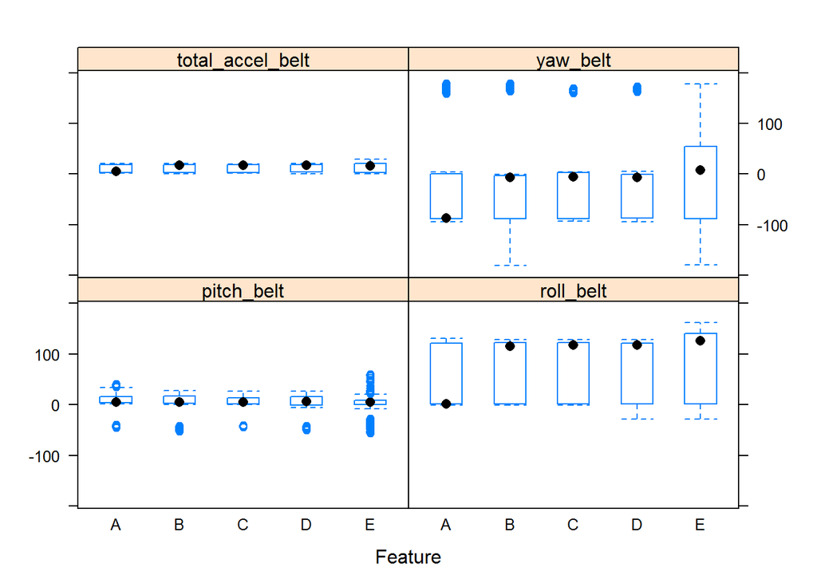

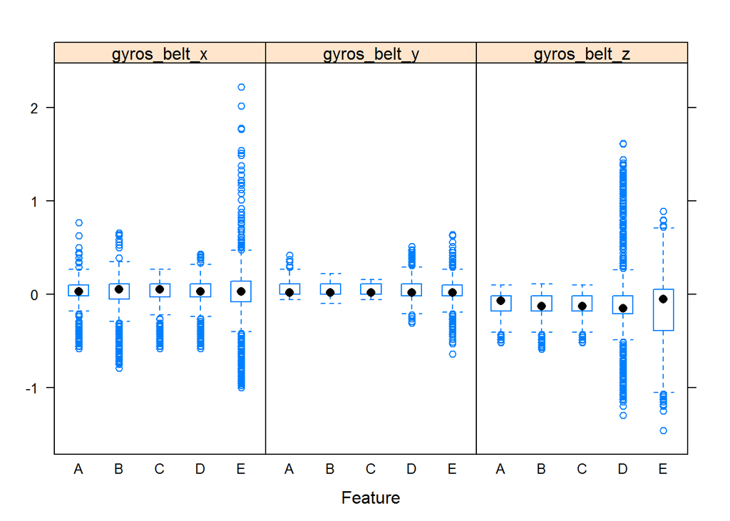

## NearZeroVar Appendix

```
##                      freqRatio percentUnique zeroVar   nzv
## roll_belt             1.054572    7.92120413   FALSE FALSE
## pitch_belt            1.133333   11.81244364   FALSE FALSE
## yaw_belt              1.075916   12.57543178   FALSE FALSE
## total_accel_belt      1.057191    0.20115142   FALSE FALSE
## gyros_belt_x          1.040078    0.89477700   FALSE FALSE
## gyros_belt_y          1.152654    0.45779288   FALSE FALSE
## gyros_belt_z          1.079170    1.10980093   FALSE FALSE
## accel_belt_x          1.094812    1.13060970   FALSE FALSE
## accel_belt_y          1.109139    0.96413956   FALSE FALSE
## accel_belt_z          1.080745    1.98376916   FALSE FALSE
## magnet_belt_x         1.047619    2.14330305   FALSE FALSE
## magnet_belt_y         1.110187    2.01845044   FALSE FALSE
## magnet_belt_z         1.005618    3.06582507   FALSE FALSE
## roll_arm             47.188679   16.91752792   FALSE FALSE
## pitch_arm            80.677419   19.65734896   FALSE FALSE
## yaw_arm              32.480519   18.44350420   FALSE FALSE
## total_accel_arm       1.000000    0.45085663   FALSE FALSE
## gyros_arm_x           1.020888    4.36984116   FALSE FALSE
## gyros_arm_y           1.445876    2.55254214   FALSE FALSE
## gyros_arm_z           1.041975    1.67857391   FALSE FALSE
## accel_arm_x           1.045113    5.28542693   FALSE FALSE
## accel_arm_y           1.152866    3.65540681   FALSE FALSE
## accel_arm_z           1.072917    5.35478948   FALSE FALSE
## magnet_arm_x          1.030769    9.21134771   FALSE FALSE
## magnet_arm_y          1.134328    5.97211625   FALSE FALSE
## magnet_arm_z          1.049383    8.69112853   FALSE FALSE
## roll_dumbbell         1.010309   86.37025734   FALSE FALSE
## pitch_dumbbell        2.489796   84.06048415   FALSE FALSE
## yaw_dumbbell          1.101124   85.62114171   FALSE FALSE
## total_accel_dumbbell  1.087045    0.28438649   FALSE FALSE
## gyros_dumbbell_x      1.068182    1.58840258   FALSE FALSE
## gyros_dumbbell_y      1.216895    1.85198030   FALSE FALSE
## gyros_dumbbell_z      1.088993    1.33869737   FALSE FALSE
## accel_dumbbell_x      1.040161    2.85773739   FALSE FALSE
## accel_dumbbell_y      1.043011    3.16986890   FALSE FALSE
## accel_dumbbell_z      1.134503    2.80224735   FALSE FALSE
## magnet_dumbbell_x     1.116279    7.49809253   FALSE FALSE
## magnet_dumbbell_y     1.174603    5.74321981   FALSE FALSE
## magnet_dumbbell_z     1.051471    4.64729139   FALSE FALSE
## roll_forearm         11.273438   13.26905736   FALSE FALSE
## pitch_forearm        58.897959   18.54754803   FALSE FALSE
## yaw_forearm          15.433155   12.33959908   FALSE FALSE
## total_accel_forearm   1.152245    0.45779288   FALSE FALSE
## gyros_forearm_x       1.032663    1.95602414   FALSE FALSE
## gyros_forearm_y       1.017606    4.93167788   FALSE FALSE
## gyros_forearm_z       1.149718    1.96989665   FALSE FALSE
## accel_forearm_x       1.213115    5.44496081   FALSE FALSE
## accel_forearm_y       1.069444    6.79059444   FALSE FALSE
## accel_forearm_z       1.045045    3.85655823   FALSE FALSE
## magnet_forearm_x      1.033333   10.18242353   FALSE FALSE
## magnet_forearm_y      1.063492   12.72109315   FALSE FALSE
## magnet_forearm_z      1.000000   11.17430811   FALSE FALSE
## classe                1.469388    0.03468128   FALSE FALSE
```

## R Code Appendix

### Preproccessing the Data

```r
library(caret)
##reading in the training and testing files given by Coursera
training <- read.csv('./pml-training.csv')
testing <- read.csv('./pml-testing.csv')
##table of the classe variable in the training set
table(training$classe)
##set seed for program
set.seed(1256)
##split training into training set and cross-validation set
inTrain <- createDataPartition(training$classe, p=3/4, list=FALSE)
trainSet <- training[inTrain,]
testSet <- training[-inTrain,]

##Look at structure of the dataset
str(trainSet,list.len=ncol(trainSet))

##Summary of variables
summary(trainSet)

##Feature Plots of the other 52 variables
featurePlot(x=trainSet[,c("roll_belt","pitch_belt","yaw_belt","total_accel_belt")],y=trainSet$classe,plot="box")
featurePlot(x=trainSet[,c("gyros_belt_x","gyros_belt_y","gyros_belt_z")],y=trainSet$classe,plot="box")
featurePlot(x=trainSet[,c("accel_belt_x","accel_belt_y","accel_belt_z")],y=trainSet$classe,plot="box")
featurePlot(x=trainSet[,c("magnet_belt_x", "magnet_belt_y","magnet_belt_z")],y=trainSet$classe,plot="box")
featurePlot(x=trainSet[,c("roll_arm","pitch_arm","yaw_arm","total_accel_arm")],y=trainSet$classe,plot="box")
featurePlot(x=trainSet[,c("gyros_arm_x","gyros_arm_y","gyros_arm_z")],y=trainSet$classe,plot="box")
featurePlot(x=trainSet[,c("accel_arm_x","accel_arm_y","accel_arm_z")],y=trainSet$classe,plot="box")
featurePlot(x=trainSet[,c("magnet_arm_x","magnet_arm_y","magnet_arm_z")],y=trainSet$classe,plot="box")
featurePlot(x=trainSet[,c("roll_arm","pitch_dumbbell","yaw_dumbbell","total_accel_dumbbell")],y=trainSet$classe,plot="box")
featurePlot(x=trainSet[,c("roll_dumbbell","pitch_dumbbell","yaw_dumbbell","total_accel_dumbbell")],y=trainSet$classe,plot="box")
featurePlot(x=trainSet[,c("gyros_dumbbell_x","gyros_dumbbell_y","gyros_dumbbell_z")],y=trainSet$classe,plot="box")
featurePlot(x=trainSet[,c("accel_dumbbell_x", "accel_dumbbell_y", "accel_dumbbell_z")],y=trainSet$classe,plot="box")
featurePlot(x=trainSet[,c("magnet_dumbbell_x", "magnet_dumbbell_y", "magnet_dumbbell_z")],y=trainSet$classe,plot="box")

featurePlot(x=trainSet[,c("roll_forearm","pitch_forearm","yaw_forearm","total_accel_forearm")],y=trainSet$classe,plot="box")
featurePlot(x=trainSet[,c("gyros_forearm_x","gyros_forearm_y","gyros_forearm_z")],y=trainSet$classe,plot="box")
featurePlot(x=trainSet[,c("accel_forearm_x", "accel_forearm_y", "accel_forearm_z")],y=trainSet$classe,plot="box")
featurePlot(x=trainSet[,c("magnet_forearm_x", "magnet_forearm_y", "magnet_forearm_z")],y=trainSet$classe,plot="box")

##Only use new window == no
subsetTrainSet <- trainSet[trainSet$new_window == "no",]

##Subset out the 53 columns needed for prediction
subsetTrainSet <- subsetTrainSet[,c("roll_belt", "pitch_belt", "yaw_belt", "total_accel_belt", "gyros_belt_x", "gyros_belt_y", "gyros_belt_z", "accel_belt_x", "accel_belt_y", "accel_belt_z", "magnet_belt_x", "magnet_belt_y", "magnet_belt_z", "roll_arm", "pitch_arm", "yaw_arm", "total_accel_arm", "gyros_arm_x", "gyros_arm_y", "gyros_arm_z", "accel_arm_x", "accel_arm_y", "accel_arm_z", "magnet_arm_x", "magnet_arm_y", "magnet_arm_z", "roll_dumbbell", "pitch_dumbbell", "yaw_dumbbell", "total_accel_dumbbell", "gyros_dumbbell_x", "gyros_dumbbell_y", "gyros_dumbbell_z", "accel_dumbbell_x", "accel_dumbbell_y", "accel_dumbbell_z", "magnet_dumbbell_x", "magnet_dumbbell_y", "magnet_dumbbell_z", "roll_forearm", "pitch_forearm", "yaw_forearm", "total_accel_forearm", "gyros_forearm_x", "gyros_forearm_y", "gyros_forearm_z", "accel_forearm_x", "accel_forearm_y", "accel_forearm_z", "magnet_forearm_x", "magnet_forearm_y", "magnet_forearm_z", "classe")]

##Check if any covariates are near zero
nzv <- nearZeroVar(subsetTrainSet,saveMetrics=TRUE)
nzv
```

### Predicting

```r
#Predict on training set using random forests
modFit <- train(classe~.,data=subsetTrainSet,method="rf")
##Look at model fit
modFit
```

### Cross-Validation

```r
##Subset test set in the same way as training set
subsetTestSet <- testSet[testSet$new_window == "no",]
subsetTestSet <- subsetTestSet[,c("roll_belt", "pitch_belt", "yaw_belt", "total_accel_belt", "gyros_belt_x", "gyros_belt_y", "gyros_belt_z", "accel_belt_x", "accel_belt_y", "accel_belt_z", "magnet_belt_x", "magnet_belt_y", "magnet_belt_z", "roll_arm", "pitch_arm", "yaw_arm", "total_accel_arm", "gyros_arm_x", "gyros_arm_y", "gyros_arm_z", "accel_arm_x", "accel_arm_y", "accel_arm_z", "magnet_arm_x", "magnet_arm_y", "magnet_arm_z", "roll_dumbbell", "pitch_dumbbell", "yaw_dumbbell", "total_accel_dumbbell", "gyros_dumbbell_x", "gyros_dumbbell_y", "gyros_dumbbell_z", "accel_dumbbell_x", "accel_dumbbell_y", "accel_dumbbell_z", "magnet_dumbbell_x", "magnet_dumbbell_y", "magnet_dumbbell_z", "roll_forearm", "pitch_forearm", "yaw_forearm", "total_accel_forearm", "gyros_forearm_x", "gyros_forearm_y", "gyros_forearm_z", "accel_forearm_x", "accel_forearm_y", "accel_forearm_z", "magnet_forearm_x", "magnet_forearm_y", "magnet_forearm_z", "classe")]

str(subsetTestSet)
```

## Predicting on the Cross-Validation

```r
pred <- predict(modFit,subsetTestSet)
subsetTestSet$predRight <- pred==subsetTestSet$classe
table(pred,subsetTestSet$classe)
```